# Deceptive Version - America’s unique gun violence problem

Preethi S Ranganathan

5/14/2018

**Data Product:** America’s unique gun violence problem https://www.vox.com/policy-and-politics/2017/10/2/16399418/us-gun-violence-statistics-maps-charts

The data product, is about the Gun Violence in the United States. The maps and charts in the data product show what gun violence looks like compared with the rest of the world and also how prevalent it is in the US, why it happens, and why it’s such a tough problem to fix.

Here, I present a deceptive version of the claims made in the data product. I have picked three arguments from the product and made misleading graphs based on them.

```r
library(dplyr)
library(ggplot2)
library(gdata)
library(gridExtra)
library(stringr)
library(varhandle)
library(ggpubr)
```

**Deceptive chart argument 1:** Homicide rates have declined over years whereas firearm homicide rates have not (there is no increasing/decreasing trend over years).

**Actual Argument 1:** Gun homicides (like all homicides) have declined over the years.(Chart 9)

To explain the importance of gun violence in the US, it is better, if we show the audience that the gun violence has increased over the years instead of showing the opposite.

So, I decided to limit the time period which has a constant trend (neither increasing nor decreasing) of homicide rate.

**Improvement:** It would have been a lot better if we have shown increasing trend of homicide rates. Unfortunately, we don’t have such data.

**Datasets:** Firearm and Non-firearm homicides- https://webappa.cdc.gov/sasweb/ncipc/mortrate10_us.html

**Note:** Here, homicides does not include deaths inflicted by the police or other law-enforcing agents in the course of arresting or attempting to arrest lawbreakers.

```r
firearmhomicidefiles <- list.files(path='~/Documents/Santa Clara/data viz/indiv proj/homicide',full.names = TRUE, pattern = ".csv")
d=data.frame()
for(i in 1:length(firearmhomicidefiles)){
  d=rbind(read.table(firearmhomicidefiles[i],sep=',',header=TRUE),d)
}
firearm_homicide=data.frame(d[,6],d[,9],d[,10])
firearm_homicide=unique(firearm_homicide)
colnames(firearm_homicide)<- c('Year','Deaths','Population')
firearm_homicide$Firearm_type='Firearm Homicide'
```

```r
nonfirearmhomicidefiles <- list.files(path='~/Documents/Santa Clara/data viz/indiv proj/non-firearm-homicides',full.names = TRUE, pattern = ".csv")
d=data.frame()
for(i in 1:length(nonfirearmhomicidefiles)){
  d=rbind(read.table(nonfirearmhomicidefiles[i],sep=',',header=TRUE),d)
}
nonfirearm_homicides=data.frame(d[,7],d[,9],d[,10])
nonfirearm_homicides=unique(nonfirearm_homicides)
colnames(nonfirearm_homicides)<- c('Year','Deaths','Population')
nonfirearm_homicides$Firearm_type='Non-Firearm Homicide'
```

#Merge and normalized

```r
homicides=merge(firearm_homicide, nonfirearm_homicides ,by.x='Year',by.y='Year',all=TRUE)
homicides=data.frame(homicides[,1],homicides[,2],homicides[,3],homicides[,4])
colnames(homicides)<-c('Year','Firearm','Population','Nonfirearm')
homicides$Firearm_norm<-(homicides$Firearm/homicides$Population)*100000
homicides$NonFirearm_norm<-(homicides$Nonfirearm/homicides$Population)*100000
```

#Combining firearm and non-firearm homicides

```r
homicides1=rbind(firearm_homicide,nonfirearm_homicides)
homicides1$norm<-(homicides1$Deaths/homicides1$Population)*100000
```

**Deceptive plot:**

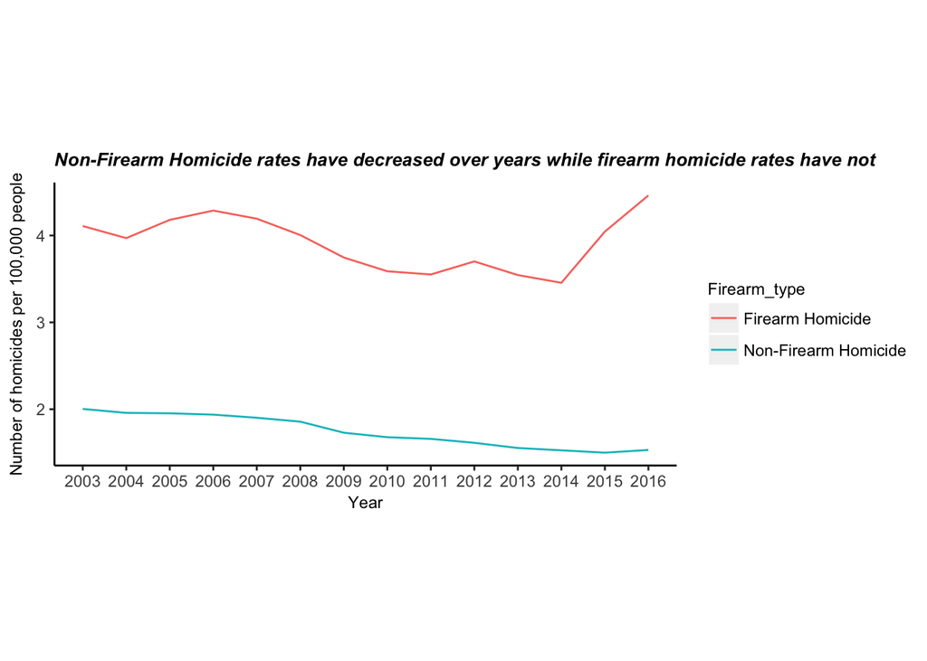

```r
homcides_cut=homicides1[homicides1$Year>2002,]

ggplot(homcides_cut) +geom_line(aes(Year, norm,color=Firearm_type ))+ggtitle('Non-Firearm Homicide rates have decreased over years while firearm homicide rates have not')+theme(panel.grid.major = element_blank(), panel.grid.minor = element_blank(), panel.background = element_blank(),  axis.line = element_line(colour = "black"), plot.title = element_text( size=10, face="bold.italic"),axis.title= element_text( size=9),legend.title= element_text( size=9))+ labs(x='Year',y = "Number of homicides per 100,000 people")+ scale_x_continuous(breaks=seq(2003,2017,1))+coord_fixed(ratio = 2)
```

**Smoothened Deceptive plot:**

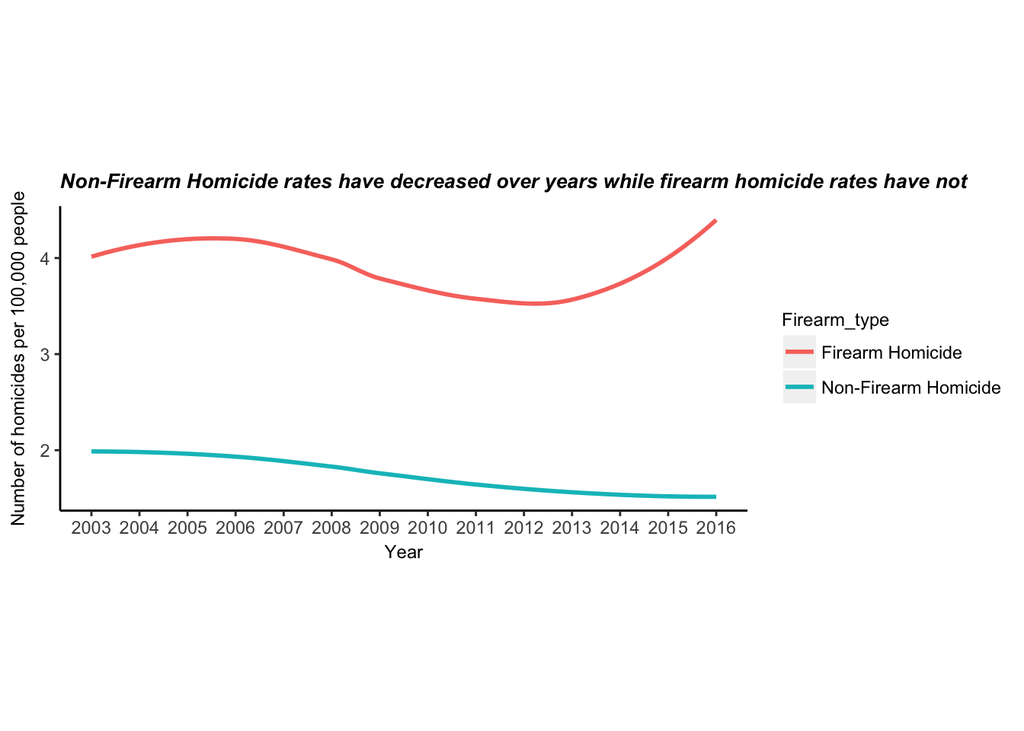

```r
ggplot(homcides_cut) +geom_smooth(aes(Year, norm,color=Firearm_type), se=FALSE)+ggtitle('Non-Firearm Homicide rates have decreased over years while firearm homicide rates have not ')+theme(panel.grid.major = element_blank(), panel.grid.minor = element_blank(), panel.background = element_blank(), axis.line = element_line(colour = "black"), plot.title = element_text( size=10, face="bold.italic"),axis.title= element_text( size=9),legend.title= element_text( size=9))+ labs(x='Year',y = "Number of homicides per 100,000 people")+scale_x_continuous(breaks=seq(2003,2017,1))+coord_fixed(ratio = 2)
```

**Actual Plot (1981-2016):**

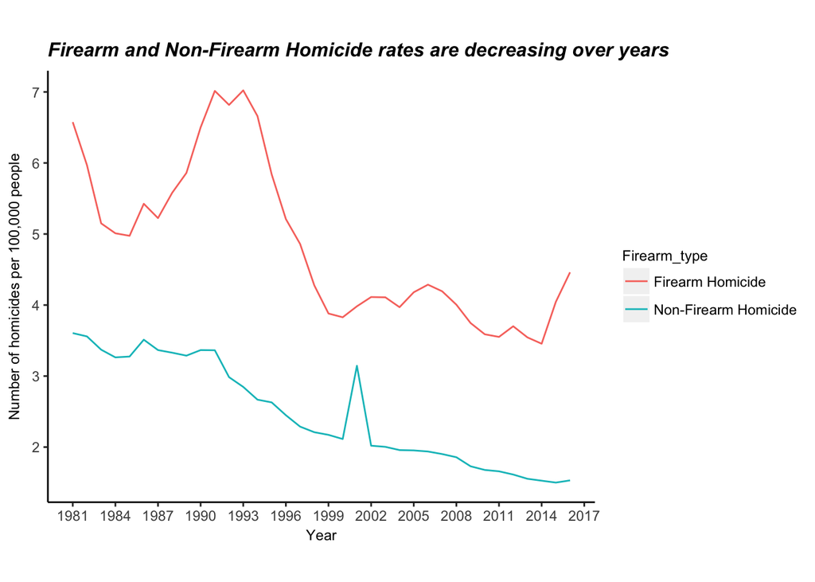

```r
ggplot(homicides1) +geom_line(aes(Year, norm,color=Firearm_type ))+ggtitle('Firearm and Non-Firearm Homicide rates are decreasing over years ')+theme(panel.grid.major = element_blank(), panel.grid.minor = element_blank(), panel.background = element_blank(), axis.line = element_line(colour = "black"), plot.title = element_text( size=12, face="bold.italic"),axis.title= element_text( size=9),legend.title= element_text( size=9))+ labs(x='Year',y = "Number of homicides per 100,000 people")+ scale_x_continuous(breaks=seq(1981,2017,3))+ coord_fixed(ratio = 5)
```

**Actual plot (1981-2016 -Smoothened):**

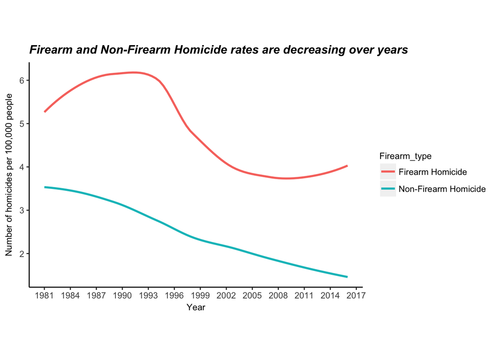

```r
ggplot(homicides1) +geom_smooth(aes(Year, norm,color=Firearm_type), se=FALSE)+ggtitle('Firearm and Non-Firearm Homicide rates are decreasing over years ')+theme(panel.grid.major = element_blank(), panel.grid.minor = element_blank(), panel.background = element_blank(), axis.line = element_line(colour = "black"), plot.title = element_text( size=12, face="bold.italic"),axis.title= element_text( size=9),legend.title= element_text( size=9))+ labs(x='Year',y = "Number of homicides per 100,000 people")+ scale_x_continuous(breaks=seq(1981,2017,3))+coord_fixed(ratio = 5)
```

**Deceptive Argument 2:** Tighter gun control laws does not reduce the number of gun-related deaths.

**Actual Argument:** States with tighter gun control laws have fewer gun-related deaths.

This is one of the main claims made by the data product. So, I picked this chart and made a decptive version out of it.

I picked the states with high gun control laws and states with less gun control laws to see a clear difference in gun deaths between states with high gun control laws and low gun control laws. Here, I normalized the number of deaths in each state per 100,000 people so that the population of each state is taken into consideration. I also noticed that death rate was not dependent on population in this chart.

Hence, I decided to make a deceptive chart without normalizing for population ie.,I made the y axis as raw number of deaths, not death rate per 100,000 people. As I expected, the chart showed that states with high gun control laws has no correlation with gun deaths.

**Improvement:** It would have been better, if I had picked few states where gun deaths are prevalent and plotted a time trend of change in number of control laws and change in gun deaths over years. There could be numerous factors in each state, which could cause an increase in gun deaths. By comparing gun deaths of one state across different years, we control for other factors causing gun deaths in different states.

**Datasets:** Gun control laws - https://www.statefirearmlaws.org/table.html Gun deaths- https://www.cdc.gov/nchs/pressroom/sosmap/firearm_mortality/firearm.htm

**Note:** Here, I have considered statewise number of gun control laws and gun deaths in 2014.

#Gun control laws by state vs Gun Deaths

```r
# Gun control laws for each state and year
gun_control=read.csv('~/Documents/Santa Clara/data viz/indiv proj/raw_data.csv',header=TRUE)

# Gun control for 2014
gun_control=gun_control[gun_control[,2]==2014,]
gun_control=data.frame(gun_control[,1],gun_control[,136])
colnames(gun_control)<-c('State','Number_laws')

# Statewise gun death data -2014
gundeaths2014=read.xls('~/Documents/Santa Clara/data viz/indiv proj/Gun_Deaths_statewise.xlsx',header=TRUE, sheet=2)

# Filtering states with high number of gun control laws
highlaws=data.frame(gun_control[order(-gun_control$Number_laws),][1:10,])
lesslaws=data.frame(gun_control[order(gun_control$Number_laws),][1:10,])
highlaws$Number_GunControl_Laws='high'
lesslaws$Number_GunControl_Laws='low'
highlow=rbind(highlaws,lesslaws)

# Merging data sets
gun_control_deaths=merge(gundeaths2014, highlow ,by.x='STATE.NAME',by.y='State')
guncontrol_deaths=data.frame(gun_control_deaths[,2], gun_control_deaths[,3], gun_control_deaths[,4], gun_control_deaths[,6], gun_control_deaths[,10])
colnames(guncontrol_deaths)<-c("State",'population','Deathrate','Deaths_num','Number_of_gun_control_laws')
guncontrol_deaths$population<-as.numeric(str_replace_all(guncontrol_deaths$population,",",""))
```

**Deceptive plot:**

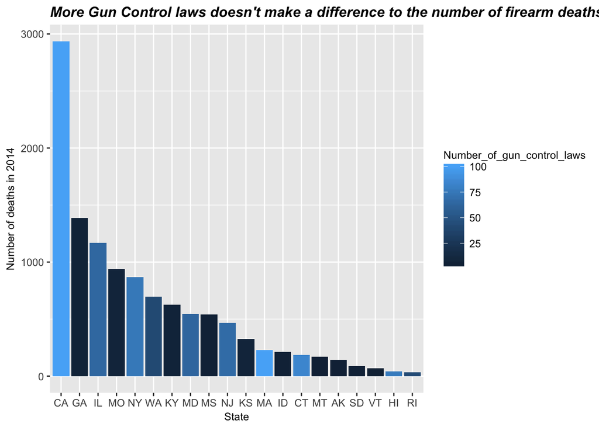

```r
ggplot(guncontrol_deaths, aes(reorder(State, -Deaths_num), Deaths_num , fill=Number_of_gun_control_laws)) +geom_col(position ='dodge') +ggtitle('More Gun Control laws doesn\'t make a difference to the number of firearm deaths')+theme(plot.title = element_text( size=12, face="bold.italic"),axis.title= element_text( size=9),legend.title= element_text(size=9))+ labs(x='State',y = "Number of deaths in 2014")
```

**Actual plot:**

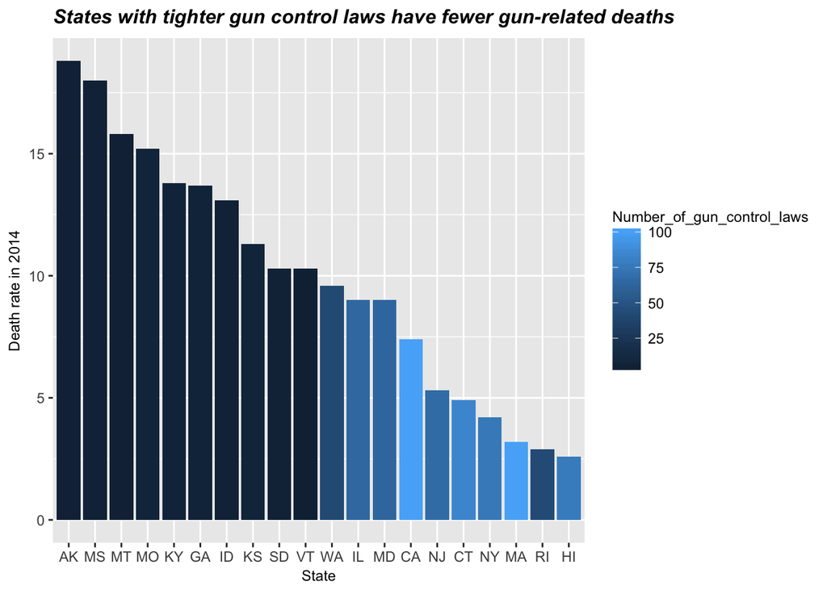

```r
ggplot(guncontrol_deaths, aes(reorder(State, -Deathrate), Deathrate , fill=Number_of_gun_control_laws)) +geom_col(position ='dodge') +ggtitle('States with tighter gun control laws have fewer gun-related deaths')+theme(plot.title = element_text( size=12, face="bold.italic"),axis.title= element_text( size=9),legend.title= element_text( size=9))+ labs(x='State',y = "Death rate in 2014")
```

**Deceptive Argument 3:** As the number of gun control laws has increased in the US over years, gun violence has reduced. New legal restrictions on owning and purchasing guns tended to be followed by a drop in gun violence — a strong indicator that restricting access to guns can save lives.

This argument is from the data product, but this is also deceptive.

**Actual Argument:** The actual argument (suggested by me) is that restricting access to guns has not saved lives. Gun violence has increased as the number of gun control laws has increased over years.

The deceptive argument presented in the data product did not take into account, the total number of firearm violence as a sum of gun homicides, suicides and non-fatal injuries.

The entire data product is just focussing on the homicide rates or suicides rates seperately, sometimes both. But, it never considered the number of gun injuries. So, I tried plotting the total firearam casualties as a sum of gun homicides, suicides and non-fatal injuries which clearly showed that there has been an increasing trend of gun casualties over years.

The decrease in homicide rate could be due to improved medical facilities and emergency services in the recent years. https://www.umass.edu/newsoffice/article/research-finds-us-murder-rate-suppressed-improved-emergency-medical-response

**Improvement:** This could be verified by importing a Emergency Medical Service (EMS) dataset, and checking the trend to correlate with decrease in homicide rate.

**Datasets**: Firearm casualties- https://webappa.cdc.gov/sasweb/ncipc/mortrate10_us.html Gun control laws- https://www.statefirearmlaws.org/table.html

```r
# Non-fatal gun injury
gun_injuryfiles <- list.files(path='~/Documents/Santa Clara/data viz/indiv proj/firearm_injuries',full.names = TRUE, pattern = ".csv")
d=data.frame()
for(i in 1:length(gun_injuryfiles)){
  d=rbind(read.table(gun_injuryfiles[i],sep=',',header=TRUE),d)
}
gun_injury=data.frame(d[,4],d[,7])
colnames(gun_injury)<-c('Year','Number_injuries')
gun_injury=gun_injury[gun_injury$Year>2000&gun_injury$Year<2015,]
gun_injury$Number_injuries=as.integer(str_replace_all(unfactor(gun_injury$Number_injuries),',',''))

# Gun homicides
firearmhomicidefiles <- list.files(path='~/Documents/Santa Clara/data viz/indiv proj/homicide',full.names = TRUE, pattern = ".csv")
d=data.frame()
for(i in 1:length(firearmhomicidefiles)){
  d=rbind(read.table(firearmhomicidefiles[i],sep=',',header=TRUE),d)
}
firearm_homicide=data.frame(d[,6],d[,9],d[,10])
firearm_homicide=unique(firearm_homicide)
colnames(firearm_homicide)<- c('Year','Homicides','Population')
firearm_homicide=firearm_homicide[firearm_homicide$Year>2000&gun_injury$Year<2015,]
# Gun suicides
suicidefiles <- list.files(path='~/Documents/Santa Clara/data viz/indiv proj/suicide',full.names = TRUE, pattern = ".csv")
d=data.frame()
for(i in 1:length(suicidefiles)){
  d=rbind(read.table(suicidefiles[i],sep=',',header=TRUE),d)
}
suicide=data.frame(d[,6],d[,9])
suicide=unique(suicide)
colnames(suicide)<- c('Year','Suicides')
suicide=suicide[suicide$Year>2000&gun_injury$Year<2015,]
## Total firearam casualties as a sum of gun homicides, suicides and non-fatal injuries
gun_casualties<-merge(firearm_homicide,suicide,by.x='Year',by.y='Year')
gun_casualties<-merge(gun_casualties,gun_injury,by.x='Year',by.y='Year')
gun_casualties$Total_casualties<-gun_casualties$Homicides+gun_casualties$Suicides+gun_casualties$Number_injuries
gun_casualties$Total_casualties_rate<-(gun_casualties$Total_casualties/gun_casualties$Population)*100000
gun_casualties$Homicide_rate<-(gun_casualties$Homicides)*100000/gun_casualties$Population
```

#Gun control laws vs Gun Violence over years

```r
gun_control=read.csv('~/Documents/Santa Clara/data viz/indiv proj/raw_data.csv',header=TRUE)
gun_control=data.frame(gun_control[,2],gun_control[,136])
colnames(gun_control)<-c('Year','Number_laws')
gun_control=gun_control %>% group_by(Year) %>% summarize(Number_laws=sum(Number_laws))

homicides_control=merge(gun_casualties, gun_control ,by.x='Year',by.y='Year',all=TRUE)
homicides_control=homicides_control[complete.cases(homicides_control),]
```

**Deceptive plot:**

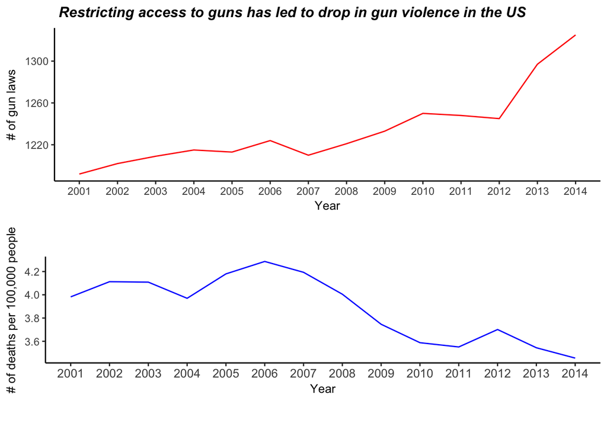

```r
p9=ggplot(homicides_control) +geom_line(aes(Year, Homicide_rate ),col='blue')+theme(panel.grid.major = element_blank(), panel.grid.minor = element_blank(), panel.background = element_blank(),axis.line = element_line(colour = "black"),plot.title = element_text( size=12, face="bold.italic"),axis.title= element_text( size=10))+ labs(x='Year',y = "# of deaths per 100,000 people")+ scale_x_continuous(breaks=seq(2001,2014,1))+ coord_fixed(ratio = 3)

p11=ggplot(homicides_control) +geom_line(aes(Year, Number_laws ),col='red')+ggtitle(' Restricting access to guns has led to drop in gun violence in the US')+theme(panel.grid.major = element_blank(), panel.grid.minor = element_blank(), panel.background = element_blank(),axis.line = element_line(colour = "black"),plot.title = element_text( size=12, face="bold.italic"),axis.title= element_text(size=10))+ labs(x='Year',y = "# of gun laws") + scale_x_continuous(breaks=seq(2001,2014,1))

ggarrange(p11, p9 + font("x.text", size = 10),
                    ncol = 1, nrow = 2)
```

**Actual plot:**

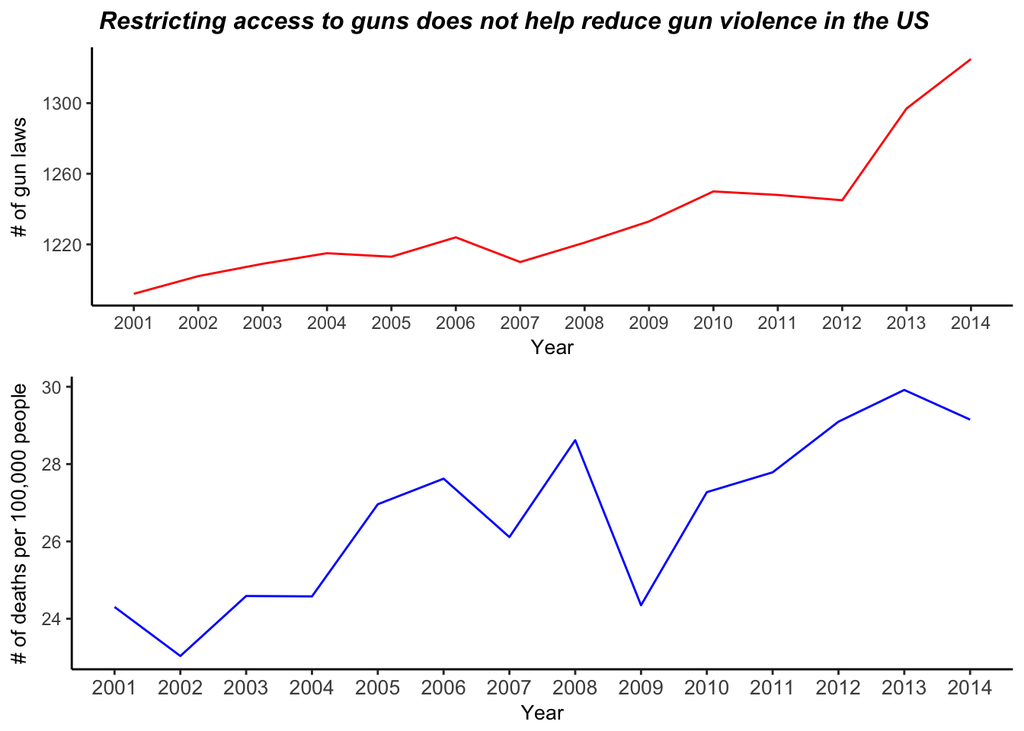

```r
p10=ggplot(homicides_control) +geom_line(aes(Year, Total_casualties_rate ),col='blue')+theme(panel.grid.major = element_blank(), panel.grid.minor = element_blank(), panel.background = element_blank(),axis.line = element_line(colour = "black"),plot.title = element_text( size=12, face="bold.italic"),axis.title= element_text( size=10),legend.title= element_text( size=10, face="bold.italic"))+ labs(x='Year',y = "# of deaths per 100,000 people")+ scale_x_continuous(breaks=seq(2001,2014,1))

p11=ggplot(homicides_control) +geom_line(aes(Year, Number_laws ),col='red')+ggtitle(' Restricting access to guns does not help reduce gun violence in the US')+theme(panel.grid.major = element_blank(), panel.grid.minor = element_blank(), panel.background = element_blank(),axis.line = element_line(colour = "black"),plot.title = element_text( size=12, face="bold.italic"),axis.title= element_text(size=10))+ labs(x='Year',y = "# of gun laws") + scale_x_continuous(breaks=seq(2001,2014,1))

ggarrange(p11, p10 + font("x.text", size = 10),
                    ncol = 1, nrow = 2)
```